# PW3 : Logistic Regression

Florian Marc, ESILV A4 IBO4

5 octobre 2018

For this practical work, I’ll be using the packages `knitr` and `kableExtra` for formatting the report.

**1.** Import dataset

```r
SNA = read.csv("Social_Network_Ads.csv", header = TRUE, sep = ",")
```

**2.** Describe dataset

```r
str(SNA)
```

```
## 'data.frame':    400 obs. of  5 variables:
##  $ User.ID        : int  15624510 15810944 15668575 15603246 15804002 15728773 15598044 15694829 15600575 15727311 ...
##  $ Gender         : Factor w/ 2 levels "Female","Male": 2 2 1 1 2 2 1 1 2 1 ...
##  $ Age            : num  19 35 26 27 19 27 27 32 25 35 ...
##  $ EstimatedSalary: num  19000 20000 43000 57000 76000 58000 84000 150000 33000 65000 ...
##  $ Purchased      : int  0 0 0 0 0 0 0 1 0 0 ...
```

```r
summary(SNA)
```

[output not shown]

[output not shown]

[output not shown]

EstimatedSalary

Purchased

Min. :15566689

Female:204

Min. :18.00

Min. : 15000

Min. :0.0000

1st Qu.:15626764

Male :196

1st Qu.:29.75

1st Qu.: 43000

1st Qu.:0.0000

Median :15694342

NA

Median :37.00

Median : 70000

Median :0.0000

Mean :15691540

NA

Mean :37.66

Mean : 69743

Mean :0.3575

3rd Qu.:15750363

NA

3rd Qu.:46.00

3rd Qu.: 88000

3rd Qu.:1.0000

Max. :15815236

NA

Max. :60.00

Max. :150000

Max. :1.0000

The dataset has 4 explanatory variables and 400 observations. Considering the median age and revenue, we can say that 50% of the population is under 37 and earns less than 70000$ a year.

**3.** Let’s split the dataset randomly.

```r
library(caTools)
```

We’ll be using a seed so that every time the script is used, we get the same results :

```r
set.seed(seed = 123)
```

The data set is split randomly with a **75%** training, **25%** testing ratio.

```r
split = sample.split(SNA$Purchased, SplitRatio = 0.75)
unscaled_training_set = subset(SNA, split == TRUE)
unscaled_testing_set = subset(SNA, split == FALSE)
```

__4.__According to the subject, the inputs of the dataset are `Age` and `Estimated Salary`. Let’s copy our dataset first

```r
training_set = unscaled_training_set
testing_set = unscaled_testing_set
```

In order to be able to interpret the Intersect value of our model, we must first scale our inputs(i.e. normalize them):

```r
training_set[c(3,4)] = scale(unscaled_training_set[c(3,4)])
testing_set[c(3,4)] = scale(unscaled_testing_set[c(3,4)])
```

Let’s summarize the two models to see the difference

```r
summary(unscaled_training_set[c(3,4)])
summary(training_set[c(3,4)])
```

[output not shown]

EstimatedSalary

Min. :18.00

Min. : 15000

1st Qu.:30.00

1st Qu.: 43000

Median :37.00

Median : 71000

Mean :37.47

Mean : 70623

3rd Qu.:45.00

3rd Qu.: 88000

Max. :60.00

Max. :150000

[output not shown]

EstimatedSalary

Min. :-1.86115

Min. :-1.58750

1st Qu.:-0.71387

1st Qu.:-0.78838

Median :-0.04462

Median : 0.01075

Mean : 0.00000

Mean : 0.00000

3rd Qu.: 0.72024

3rd Qu.: 0.49593

Max. : 2.15435

Max. : 2.26543

**5.** Let’s perform a simple logistic regression of `Purchased` by `Age` on our dataset.

```r
model = glm(Purchased ~ Age, family = binomial, data = training_set)
summary(model)
```

```
##
## Call:
## glm(formula = Purchased ~ Age, family = binomial, data = training_set)
##
## Deviance Residuals:
##     Min       1Q   Median       3Q      Max
## -2.5341  -0.6641  -0.2950   0.5437   2.4392
##
## Coefficients:
##             Estimate Std. Error z value Pr(>|z|)
## (Intercept)  -0.9299     0.1672  -5.562 2.67e-08 ***
## Age           1.9913     0.2342   8.502  < 2e-16 ***
## ---
## Signif. codes:  0 '***' 0.001 '**' 0.01 '*' 0.05 '.' 0.1 ' ' 1
##
## (Dispersion parameter for binomial family taken to be 1)
##
##     Null deviance: 390.89  on 299  degrees of freedom
## Residual deviance: 252.11  on 298  degrees of freedom
## AIC: 256.11
##
## Number of Fisher Scoring iterations: 5
```

```r
coef(summary(model)
```

|  | Estimate | Std. Error | z value | Pr(>\|z\|) |
| --- | --- | --- | --- | --- |
| (Intercept) | -0.9298602 | 0.1671860 | -5.561832 | 0 |
| Age | 1.9913460 | 0.2342228 | 8.501931 | 0 |

**9.** Let’s find the **AIC** of our model:

```r
AIC(model)
```

```
## [1] 256.109
```

**10.** Let’s plot `Purchased` in function of `Age`. I’ll be using the `ggplot2` package.

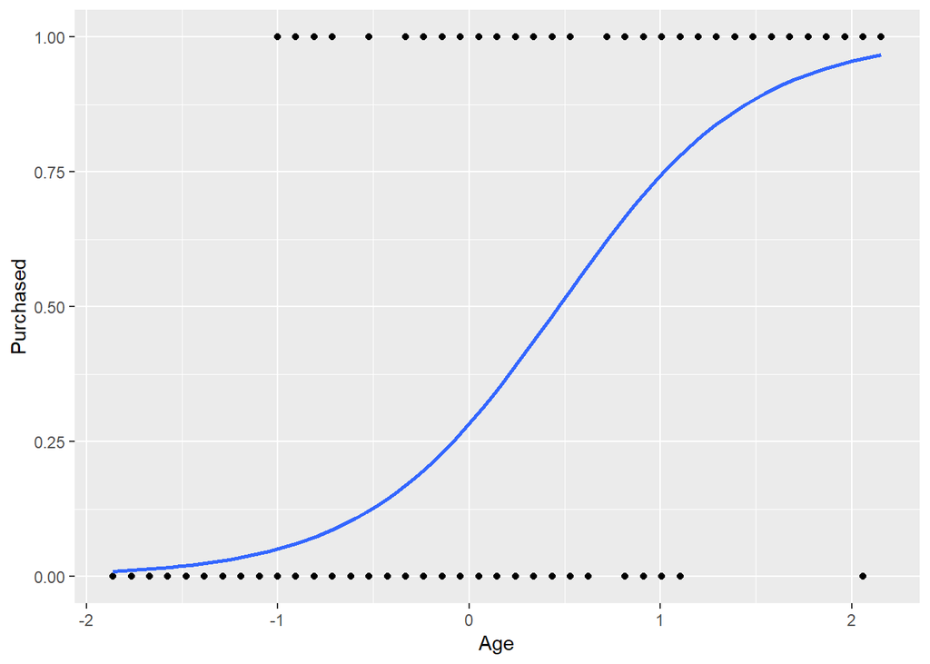

```r
library(ggplot2)
ggplot(training_set, aes(x = Age, y = Purchased))  + geom_point() + stat_smooth(method="glm", method.args=list(family="binomial"), se=FALSE)
```

**11.** Let’s perform a logistic regression of `Purchase` in function of `Age` and `EstimatedSalary`

```r
model2 = glm(Purchased ~ Age + EstimatedSalary, family = binomial, data=training_set)
```

**12.** Let’s take a look at the summary of the model :

```r
coef(summary(model2))
```

|  | Estimate | Std. Error | z value | Pr(>\|z\|) |
| --- | --- | --- | --- | --- |
| (Intercept) | -1.192286 | 0.2018132 | -5.907867 | 0 |
| Age | 2.632378 | 0.3460959 | 7.605920 | 0 |
| EstimatedSalary | 1.394676 | 0.2326102 | 5.995766 | 0 |

**14.** Let’s predict the probability of the user purchasing the product according to our second model.

```r
pred = predict(model2, newdata = testing_set[c(3,4)], type = "response")
```

**15.** Let’s take a look at the predicted values for `Purchased` by transforming them to zeros and ones (1 if > 0.5):

```r
sorted_pred = ifelse(pred > 0.5, 1, 0)
```

**16.** Let’s compute the confusion_matrix out of our predictions

```r
confusion_matrix = table(testing_set[,5], sorted_pred)
```

```
##    sorted_pred
##      0  1
##   0 57  7
##   1 10 26
```

**17.** Let’s calculate the accuracy, specificity, sensitivity and the precision of the model.

```r
accuracy = (confusion_matrix[1,1] + confusion_matrix[2,2]) / (confusion_matrix[1,1] + confusion_matrix[1,2] + confusion_matrix[2,1] + confusion_matrix[2,2])
```

```
## [1] 0.83
```

```r
specificity = confusion_matrix[2,2]  / (confusion_matrix[2,1] + confusion_matrix[2,2])
```

```
## [1] 0.7222222
```

```r
sensivity = confusion_matrix[1,1]  / (confusion_matrix[1,1] + confusion_matrix[1,2])
```

```
## [1] 0.890625
```

```r
precision = sensivity = confusion_matrix[1,1]  / (confusion_matrix[1,1] + confusion_matrix[2,1])
```

```
## [1] 0.8507463
```

**18.** Let’s plot the ROC curve and calculate AUC value.

```r
library(ROCR)
```

```r
score = prediction(pred, testing_set[,5])
performance(score, "auc")
```

```
## An object of class "performance"
## Slot "x.name":
## [1] "None"
##
## Slot "y.name":
## [1] "Area under the ROC curve"
##
## Slot "alpha.name":
## [1] "none"
##
## Slot "x.values":
## list()
##
## Slot "y.values":
## [[1]]
## [1] 0.9171007
##
##
## Slot "alpha.values":
## list()
```

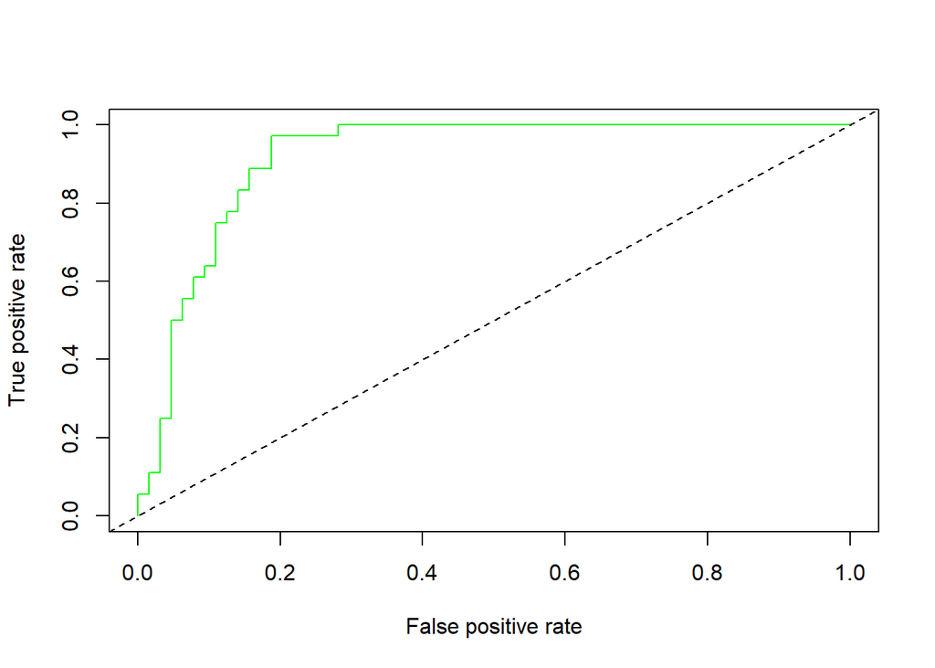

```r
plot(performance(score,"tpr","fpr"),col="green")
abline(0,1,lty=8)
```